# Prova 2 - Machine Learning

- Show All Code
- Hide All Code
- View Source

Author

Eraldo Rocha

Published

13 Oct, 2023

**Nota**

Para **TODOS** os exercícios aqui apresentados, serão utilizados os modelos de `regressão elastic`, `KNN` e `svm`. Além disso, em alguns exercícios serão removidas algumas observações para a utilização do método KNN para imputa-los novamente.

Carregando os pacotes

```r
rm(list=ls())
library(tidymodels)
tidymodels_prefer()
```

## Exercício 1

### Carregando o banco de dados:

```r
url = "https://raw.githubusercontent.com/eraldof/machine_learning/main/Student_Performance.csv"
data1 <- read.csv(url)
colnames(data1) <- c("Hours.Studied", "Previous.Scores", "Extracurricular.Activities", "Sleep.Hours", "Sample.Question.Papers.Practiced", "resultado_final")
```

### Analise exploratória:

```r
set.seed(2023)
id <- sample(1:nrow(data1), 0.1 * nrow(data1))
feature <- sample(1:(ncol(data1)-1), 2)
data1[id,feature[1]] <- NA
id <- sample(1:nrow(data1), 0.1 * nrow(data1))
data1[id, feature[2]] <- NA
rm(id)
rm(feature)
skimr::skim(data1)
```

Data summary

| Name | data1 |
| --- | --- |
| Number of rows | 10000 |
| Number of columns | 6 |
| _______________________ |  |
| Column type frequency: |  |
| character | 1 |
| numeric | 5 |
| ________________________ |  |
| Group variables | None |

**Variable type: character**

| skim_variable | n_missing | complete_rate | min | max | empty | n_unique | whitespace |
| --- | --- | --- | --- | --- | --- | --- | --- |
| Extracurricular.Activities | 0 | 1 | 2 | 3 | 0 | 2 | 0 |

**Variable type: numeric**

| skim_variable | n_missing | complete_rate | mean | sd | p0 | p25 | p50 | p75 | p100 | hist |
| --- | --- | --- | --- | --- | --- | --- | --- | --- | --- | --- |
| Hours.Studied | 1000 | 0.9 | 4.99 | 2.59 | 1 | 3 | 5 | 7 | 9 | ▇▇▃▇▇ |
| Previous.Scores | 0 | 1.0 | 69.45 | 17.34 | 40 | 54 | 69 | 85 | 99 | ▇▇▇▇▇ |
| Sleep.Hours | 0 | 1.0 | 6.53 | 1.70 | 4 | 5 | 7 | 8 | 9 | ▇▅▅▅▅ |
| Sample.Question.Papers.Practiced | 1000 | 0.9 | 4.57 | 2.87 | 0 | 2 | 5 | 7 | 9 | ▇▇▇▇▇ |
| resultado_final | 0 | 1.0 | 55.22 | 19.21 | 10 | 40 | 55 | 71 | 100 | ▂▇▇▇▂ |

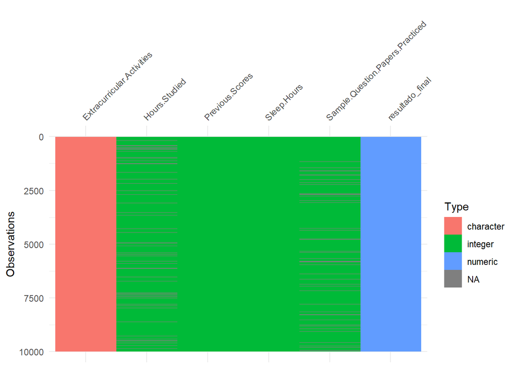

```r
visdat::vis_dat(data1)
```

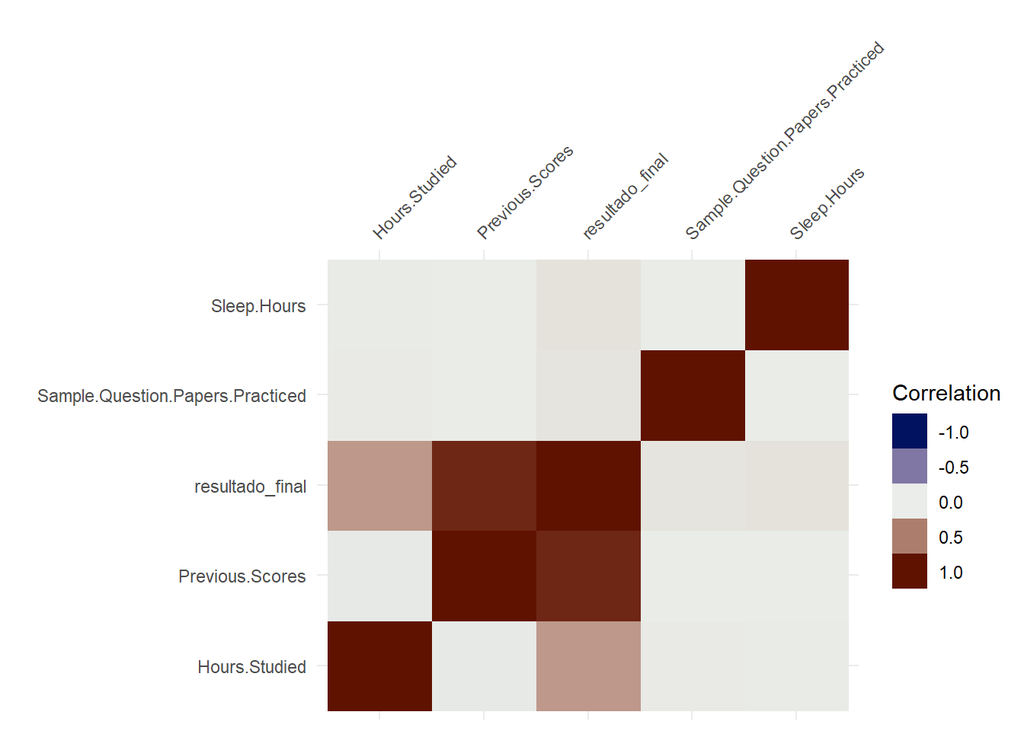

```r
visdat::vis_cor(data1[,-3])
```

O dataset possui 10 mil observações com 6 variáveis, sendo 5 do tipo númerica e 1 do tipo qualitativa nominal. Estamos interessados em prever a variável `resultado_final`, que é a nota obitida pelo aluno. Além disso, visualizando a primeira figura é possível notar que as variáveis *Horas de Estudo* e *Número de Questões Praticadas* possuem observações faltantes. Já na figura 2, vemos que uma forte correlação entre as variáveis *Resultados Anteriores* e *resultado_final*.

### Tratamento dos dados e preparação da receita:

```r
set.seed(2023)
splitted <- initial_split(data1, prop = 0.9, strata = resultado_final)
treinamento <- training(splitted)
teste <- testing(splitted)
```

```r
receita <- recipe(formula = `resultado_final` ~ . , data1) %>%
  step_impute_knn(all_predictors(),
                  impute_with = c("Previous.Scores", "Sleep.Hours", "resultado_final"),
                  neighbors = 15L) %>%
  step_dummy(`Extracurricular.Activities`)  %>%
  step_YeoJohnson(all_numeric_predictors()) %>%
  step_normalize(all_numeric_predictors())
```

**Dica:**

Com esses comandos podemos avaliar os procedimentos da receita na base de dados: `receita %>% prep() %>% juice()`

O banco de dados foi repartido em 90% para a base de treinamento e 10% para a base de teste, além disso, foi aplicado os seguintes passos na receita:

- `step_imput_knn()`: Para imputar as observações faltantes com base nas 3 variáveis numéricas que possuem total completude. Nessa etapa também poderiamos colocar um `tune()` no neighbors.
- `step_dummy()`: Para transformar a variável categórica em uma variável dummy;
- `step_YeoJohnson()`: Uma transformação similar a box-cox, entretanto mais generalizada;
- `step_normalize()`: Para normalizar as observações.

**Importante**

Na receita é necessário se atentar a ordem em que os passos são adicionados. Note que o dataset além de possuir valores faltantes, também conta com uma variável categórioca e para realizarmos as transformações é necessário que nosso dataset seja todo numérico.

### Configurando os modelos:

```r
elastic <-
  linear_reg(penalty = tune(),
             mixture = tune()
  ) %>%
  set_mode("regression") %>%
  set_engine("glmnet")

knn <-
  nearest_neighbor(
    neighbors = tune()
  ) %>%
  set_mode("regression") %>%
  set_engine("kknn")

svm <-
  svm_rbf(
    cost = tune(),
    rbf_sigma = tune(),
    margin = tune()
  ) %>%
  set_mode("regression") %>%
  set_engine("kernlab")

all_wf <-
   workflow_set(
     preproc = list(receita),
     models = list(
       modelo_knn = knn,
       modelo_svm = svm,
       modelo_elastic = elastic
     ),
     cross = TRUE
   ) %>%
  mutate(wflow_id = gsub("(recipe_)", "", wflow_id))

grid_control <- control_grid(
  save_pred = TRUE,
  save_workflow = TRUE,
  parallel_over = "resamples"
)

vfold <-
  treinamento %>%
  vfold_cv(v = 15L, strata = resultado_final)

metrica <- metric_set(rmse)
```

**Dica:**

Com a função `grid_max_entropy()` podemos criar um grid de hiperpametros mais diversificado e através do `option_add()` informamos ao workflow qual grid utilizar em cada um dos modelos.

```r
set.seed(2023)
grid_knn <- grid_max_entropy(all_wf %>% extract_parameter_set_dials("modelo_knn"), size = 50L)
grid_elastic <- grid_max_entropy(all_wf %>% extract_parameter_set_dials("modelo_elastic"), size = 100L)
grid_svm <-  grid_max_entropy(all_wf %>% extract_parameter_set_dials("modelo_svm"), size = 30L)
```

```r
all_wf <-
  all_wf %>%
  option_add(grid = grid_knn, id = 'modelo_knn') %>%
  option_add(grid = grid_elastic, id = 'modelo_elastic') %>%
  option_add(grid = grid_svm, id = 'modelo_svm')
```

### Treinamento e Seleção:

```r
tunagem <-
  all_wf %>%
  workflow_map(
    verbose = TRUE,
    seed = 2023,
    resamples = vfold,
    control = grid_control,
    metrics = metrica
  )
```

```
i 1 of 3 tuning:     modelo_knn
```

```
✔ 1 of 3 tuning:     modelo_knn (53.4s)
```

```
i 2 of 3 tuning:     modelo_svm
```

```
✔ 2 of 3 tuning:     modelo_svm (43m 1.4s)
```

```
i 3 of 3 tuning:     modelo_elastic
```

```
✔ 3 of 3 tuning:     modelo_elastic (2m 45.3s)
```

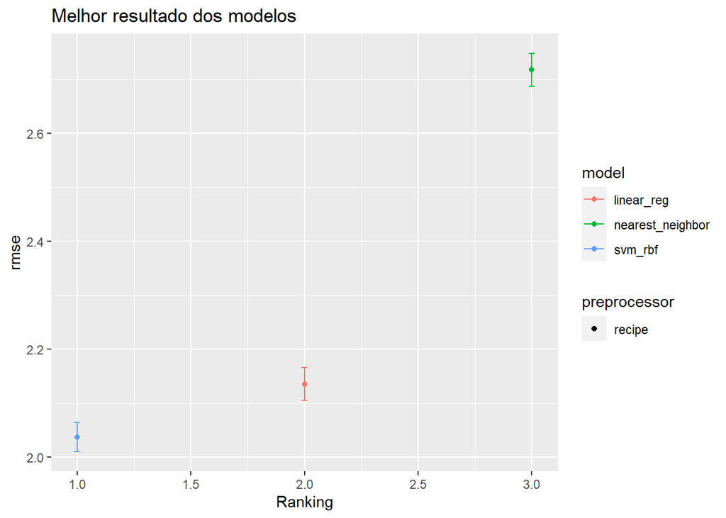

```r
autoplot(
  tunagem,
  rank_metric = "rmse",
  metric = "rmse",
  select_best = TRUE
) +
  labs(title = "Melhor resultado dos modelos")+ ylab("rmse")+ xlab("Ranking")
```

```r
best = tunagem %>%
  extract_workflow_set_result("modelo_elastic") %>%
  select_best(metric = "rmse")

best %>%
  knitr::kable(caption = "Hiperparametros")
```

Hiperparametros

| penalty | mixture | .config |
| --- | --- | --- |
| 1e-07 | 0.9970463 | Preprocessor1_Model100 |

```r
wf_final <-
  tunagem %>% extract_workflow("modelo_elastic") %>%
  finalize_workflow(best)

teste <-
  wf_final %>%
  last_fit(split = splitted)

knitr::kable(teste$.metrics, caption = "Resultados")
```

Resultados

| .metric | .estimator | .estimate | .config |
| --- | --- | --- | --- |
| rmse | standard | 2.1523423 | Preprocessor1_Model1 |
| rsq | standard | 0.9874218 | Preprocessor1_Model1 |

```r
modelo_final <-
  wf_final |>
  fit(data1)
```

## Salvando o modelo

```r
# Salvando o modelo em um arquivo serializado
#saveRDS(modelo_final, file = "modelo_final.rds")

# Lendo o arquivo serializado com o modelo final
#load(file = "modelo_final.rds")

# Fazendo novas previsões
#head(data1)
#predict(modelo_final, new_data = data1)
```

## Exercício 2

Considere o problema em que o objetivo é prever o custo, `charge`, com base em algumas variáveis. Sua análise deve conter uma análise exploratória dos dados, deverá utilizar um esquema de `k-folds` cross-validation, com `k=20` e considerar um esquema de data splitting na proporção 90% para treino e 10% para teste.

### Carregando o banco de dados

```r
url = "https://raw.githubusercontent.com/eraldof/machine_learning/main/insurance.csv"
data2 <- read.csv(url)
```

### Analise exploratória:

```r
skimr::skim(data2)
```

Data summary

| Name | data2 |
| --- | --- |
| Number of rows | 1338 |
| Number of columns | 7 |
| _______________________ |  |
| Column type frequency: |  |
| character | 3 |
| numeric | 4 |
| ________________________ |  |
| Group variables | None |

**Variable type: character**

| skim_variable | n_missing | complete_rate | min | max | empty | n_unique | whitespace |
| --- | --- | --- | --- | --- | --- | --- | --- |
| sex | 0 | 1 | 4 | 6 | 0 | 2 | 0 |
| smoker | 0 | 1 | 2 | 3 | 0 | 2 | 0 |
| region | 0 | 1 | 9 | 9 | 0 | 4 | 0 |

**Variable type: numeric**

| skim_variable | n_missing | complete_rate | mean | sd | p0 | p25 | p50 | p75 | p100 | hist |
| --- | --- | --- | --- | --- | --- | --- | --- | --- | --- | --- |
| age | 0 | 1 | 39.21 | 14.05 | 18.00 | 27.00 | 39.00 | 51.00 | 64.00 | ▇▅▅▆▆ |
| bmi | 0 | 1 | 30.66 | 6.10 | 15.96 | 26.30 | 30.40 | 34.69 | 53.13 | ▂▇▇▂▁ |
| children | 0 | 1 | 1.09 | 1.21 | 0.00 | 0.00 | 1.00 | 2.00 | 5.00 | ▇▂▂▁▁ |
| charges | 0 | 1 | 13270.42 | 12110.01 | 1121.87 | 4740.29 | 9382.03 | 16639.91 | 63770.43 | ▇▂▁▁▁ |

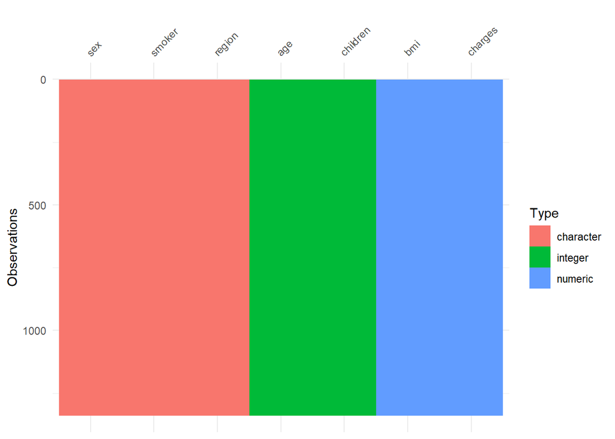

```r
visdat::vis_dat(data2)
```

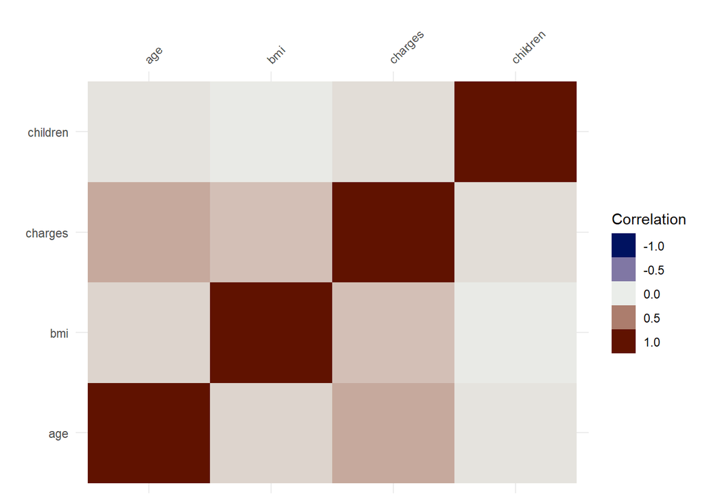

```r
visdat::vis_cor(data2[,-c(2,5,6)])
```

O dataset possui 1.338 observações com 7 variáveis, sendo 4 do tipo númerica e 3 do tipo qualitativa. Estamos interessados em prever a variável `charges` , que é o custo do seguro de vida. Além disso, visualizando a primeira figura é possível notar que não existem observações faltantes. Já na figura 2, vemos que existe pouca correlação entre as variáveis.

### Tratamento dos dados e preparação da receita:

```r
set.seed(2023)
splitted <- initial_split(data2, prop = 0.9, strata = charges)
treinamento <- training(splitted)
teste <- testing(splitted)
```

```r
receita <- recipe(formula = `charges` ~ . , data2) %>%
  step_dummy(c(`sex`, `smoker`, `region`))  %>%
  step_YeoJohnson(all_numeric_predictors()) %>%
  step_normalize(all_numeric_predictors())
```

**Dica:**

Com esses comandos podemos avaliar os procedimentos da receita na base de dados: `receita %>% prep() %>% juice()`

O banco de dados foi repartido em 90% para a base de treinamento e 10% para a base de teste, além disso, foi aplicado os seguintes passos na receita:

- `step_dummy()`: Para transformar a variável categórica em uma variável dummy;
- `step_YeoJohnson()`: Uma transformação similar a box-cox, entretanto mais generalizada;
- `step_normalize()`: Para normalizar as observações.

**Importante**

### Configurando os modelos:

```r
elastic <-
  linear_reg(penalty = tune(),
             mixture = tune()
  ) %>%
  set_mode("regression") %>%
  set_engine("glmnet")

knn <-
  nearest_neighbor(
    neighbors = tune()
  ) %>%
  set_mode("regression") %>%
  set_engine("kknn")

svm <-
  svm_rbf(
    cost = tune(),
    rbf_sigma = tune(),
    margin = tune()
  ) %>%
  set_mode("regression") %>%
  set_engine("kernlab")

all_wf <-
   workflow_set(
     preproc = list(receita),
     models = list(
       modelo_knn = knn,
       modelo_svm = svm,
       modelo_elastic = elastic
     ),
     cross = TRUE
   ) %>%
  mutate(wflow_id = gsub("(recipe_)", "", wflow_id))

grid_control <- control_grid(
  save_pred = TRUE,
  save_workflow = TRUE,
  parallel_over = "resamples"
)

vfold <-
  treinamento %>%
  vfold_cv(v = 15, strata = charges)

metrica <- metric_set(rmse)
```

**Dica:**

Com a função `grid_max_entropy()` podemos criar um grid de hiperpametros mais diversificado e através do `option_add()` informamos ao workflow qual grid utilizar em cada um dos modelos.

```r
set.seed(2023)
grid_knn <- grid_max_entropy(all_wf %>% extract_parameter_set_dials("modelo_knn"), size = 50L)
grid_elastic <- grid_max_entropy(all_wf %>% extract_parameter_set_dials("modelo_elastic"), size = 100L)
grid_svm <-  grid_max_entropy(all_wf %>% extract_parameter_set_dials("modelo_svm"), size = 30L)
```

```r
all_wf <-
  all_wf %>%
  option_add(grid = grid_knn, id = 'modelo_knn') %>%
  option_add(grid = grid_elastic, id = 'modelo_elastic') %>%
  option_add(grid = grid_svm, id = 'modelo_svm')
```

### Treinamento e Seleção:

```r
tunagem <-
  all_wf %>%
  workflow_map(
    verbose = TRUE,
    seed = 2023,
    resamples = vfold,
    control = grid_control,
    metrics = metrica
  )
```

```
i 1 of 3 tuning:     modelo_knn
```

```
✔ 1 of 3 tuning:     modelo_knn (4.5s)
```

```
i 2 of 3 tuning:     modelo_svm
```

```
✔ 2 of 3 tuning:     modelo_svm (1m 6.1s)
```

```
i 3 of 3 tuning:     modelo_elastic
```

```
✔ 3 of 3 tuning:     modelo_elastic (1m 6.2s)
```

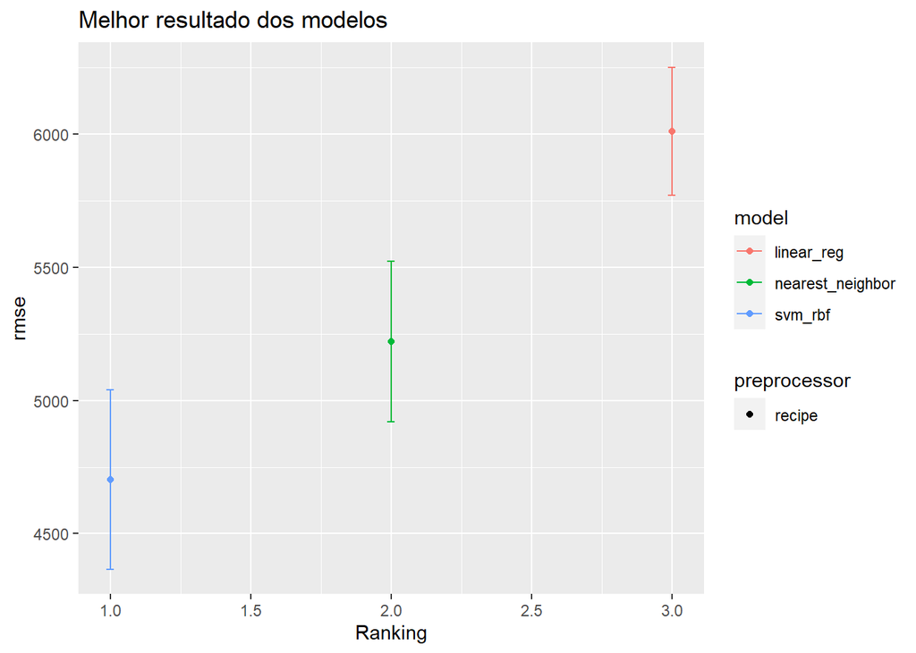

```r
autoplot(
  tunagem,
  rank_metric = "rmse",
  metric = "rmse",
  select_best = TRUE
) +
  labs(title = "Melhor resultado dos modelos")+ ylab("rmse")+ xlab("Ranking")
```

```r
best = tunagem %>%
  extract_workflow_set_result("modelo_svm") %>%
  select_best(metric = "rmse")

best %>%
  knitr::kable(caption = "Hiperparametros")
```

Hiperparametros

| cost | rbf_sigma | margin | .config |
| --- | --- | --- | --- |
| 4.091571 | 0.0184877 | 0.1154101 | Preprocessor1_Model09 |

```r
wf_final <-
  tunagem %>% extract_workflow("modelo_svm") %>%
  finalize_workflow(best)

teste <-
  wf_final %>%
  last_fit(split = splitted)

knitr::kable(teste$.metrics, caption = "Resultados")
```

Resultados

| .metric | .estimator | .estimate | .config |
| --- | --- | --- | --- |
| rmse | standard | 5359.3038279 | Preprocessor1_Model1 |
| rsq | standard | 0.8542893 | Preprocessor1_Model1 |

```r
modelo_final <-
  wf_final |>
  fit(data2)
```

## Salvando o modelo

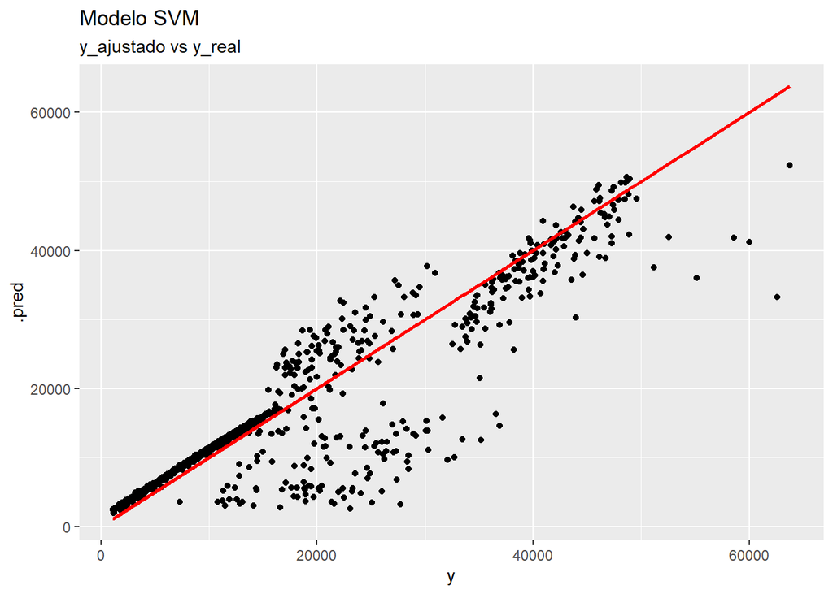

```r
# Salvando o modelo em um arquivo serializado
#saveRDS(modelo_final, file = "modelo_final.rds")

# Lendo o arquivo serializado com o modelo final
#load(file = "modelo_final.rds")

# Fazendo novas previsões
dt <- data.frame("y" = data2$charges, "yhat" = predict(modelo_final, data2))
g1 <- ggplot(dt,
             aes(x = y, y = .pred)) +
  geom_point() + geom_line(aes(y = y), colour = "red", size = 1) +
  labs(title = "Modelo SVM", subtitle = "y_ajustado vs y_real")
g1
```

## Exercício 3

Considere o problema em que o objetivo é prever a qualidade, `quality`, com base em algumas variáveis. Sua análise deve conter uma análise exploratória dos dados, utilizar um esquema de `k-folds` cross-validation, com `k=20` e considerar um esquema de data splitting na proporção 90% para treino e 10% para teste.

### Carregando o banco de dados

```r
url = "https://raw.githubusercontent.com/eraldof/machine_learning/main/winequality-red.csv"
data3 <- read.csv(url)
```

### Analise exploratória:

```r
skimr::skim(data3)
```

Data summary

| Name | data3 |
| --- | --- |
| Number of rows | 1599 |
| Number of columns | 12 |
| _______________________ |  |
| Column type frequency: |  |
| numeric | 12 |
| ________________________ |  |
| Group variables | None |

**Variable type: numeric**

| skim_variable | n_missing | complete_rate | mean | sd | p0 | p25 | p50 | p75 | p100 | hist |
| --- | --- | --- | --- | --- | --- | --- | --- | --- | --- | --- |
| fixed.acidity | 0 | 1 | 8.32 | 1.74 | 4.60 | 7.10 | 7.90 | 9.20 | 15.90 | ▂▇▂▁▁ |
| volatile.acidity | 0 | 1 | 0.53 | 0.18 | 0.12 | 0.39 | 0.52 | 0.64 | 1.58 | ▅▇▂▁▁ |
| citric.acid | 0 | 1 | 0.27 | 0.19 | 0.00 | 0.09 | 0.26 | 0.42 | 1.00 | ▇▆▅▁▁ |
| residual.sugar | 0 | 1 | 2.54 | 1.41 | 0.90 | 1.90 | 2.20 | 2.60 | 15.50 | ▇▁▁▁▁ |
| chlorides | 0 | 1 | 0.09 | 0.05 | 0.01 | 0.07 | 0.08 | 0.09 | 0.61 | ▇▁▁▁▁ |
| free.sulfur.dioxide | 0 | 1 | 15.87 | 10.46 | 1.00 | 7.00 | 14.00 | 21.00 | 72.00 | ▇▅▁▁▁ |
| total.sulfur.dioxide | 0 | 1 | 46.47 | 32.90 | 6.00 | 22.00 | 38.00 | 62.00 | 289.00 | ▇▂▁▁▁ |
| density | 0 | 1 | 1.00 | 0.00 | 0.99 | 1.00 | 1.00 | 1.00 | 1.00 | ▁▃▇▂▁ |
| pH | 0 | 1 | 3.31 | 0.15 | 2.74 | 3.21 | 3.31 | 3.40 | 4.01 | ▁▅▇▂▁ |
| sulphates | 0 | 1 | 0.66 | 0.17 | 0.33 | 0.55 | 0.62 | 0.73 | 2.00 | ▇▅▁▁▁ |
| alcohol | 0 | 1 | 10.42 | 1.07 | 8.40 | 9.50 | 10.20 | 11.10 | 14.90 | ▇▇▃▁▁ |
| quality | 0 | 1 | 5.64 | 0.81 | 3.00 | 5.00 | 6.00 | 6.00 | 8.00 | ▁▇▇▂▁ |

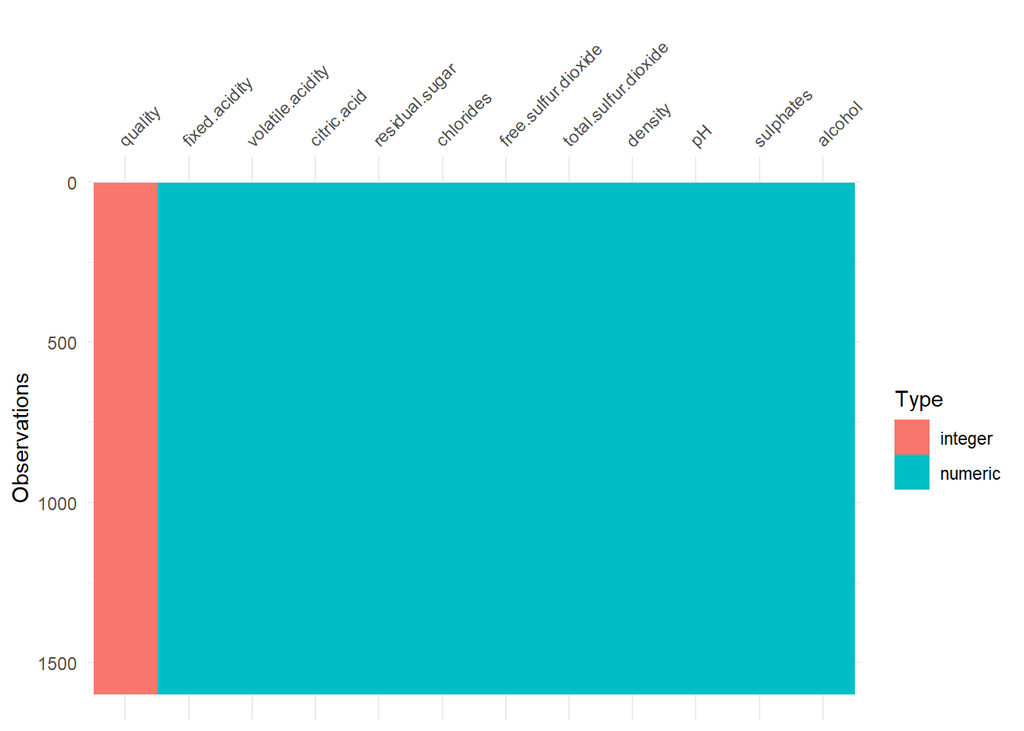

```r
visdat::vis_dat(data3)
```

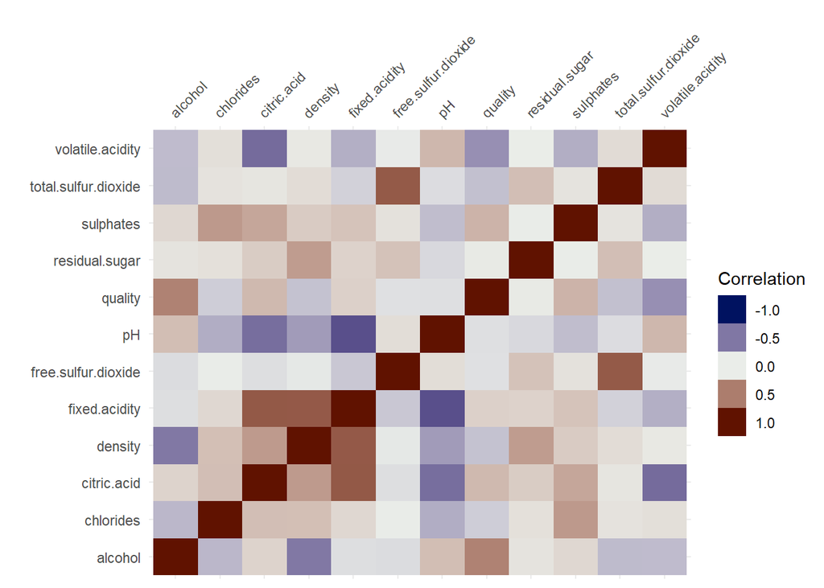

```r
visdat::vis_cor(data3)
```

### Tratamento dos dados e preparação da receita:

```r
set.seed(2023)
splitted <- initial_split(data3, prop = 0.9, strata = quality)
treinamento <- training(splitted)
teste <- testing(splitted)
```

```r
receita <- recipe(formula = `quality` ~ . , data3) %>%
  step_YeoJohnson(all_numeric_predictors()) %>%
  step_normalize(all_numeric_predictors())
```

**Dica:**

Com esses comandos podemos avaliar os procedimentos da receita na base de dados: `receita %>% prep() %>% juice()`

O banco de dados foi repartido em 90% para a base de treinamento e 10% para a base de teste, além disso, foi aplicado os seguintes passos na receita:

- `step_YeoJohnson()`: Uma transformação similar a box-cox, entretanto mais generalizada;
- `step_normalize()`: Para normalizar as observações.

**Importante**

### Configurando os modelos:

```r
elastic <-
  linear_reg(penalty = tune(),
             mixture = tune()
  ) %>%
  set_mode("regression") %>%
  set_engine("glmnet")

knn <-
  nearest_neighbor(
    neighbors = tune()
  ) %>%
  set_mode("regression") %>%
  set_engine("kknn")

svm <-
  svm_rbf(
    cost = tune(),
    rbf_sigma = tune(),
    margin = tune()
  ) %>%
  set_mode("regression") %>%
  set_engine("kernlab")

all_wf <-
   workflow_set(
     preproc = list(receita),
     models = list(
       modelo_knn = knn,
       modelo_svm = svm,
       modelo_elastic = elastic
     ),
     cross = TRUE
   ) %>%
  mutate(wflow_id = gsub("(recipe_)", "", wflow_id))

grid_control <- control_grid(
  save_pred = TRUE,
  save_workflow = TRUE,
  parallel_over = "resamples"
)

vfold <-
  treinamento %>%
  vfold_cv(v = 15, strata = quality)

metrica <- metric_set(rmse)
```

**Dica:**

Com a função `grid_max_entropy()` podemos criar um grid de hiperpametros mais diversificado e através do `option_add()` informamos ao workflow qual grid utilizar em cada um dos modelos.

```r
set.seed(2023)
grid_knn <- grid_max_entropy(all_wf %>% extract_parameter_set_dials("modelo_knn"), size = 50L)
grid_elastic <- grid_max_entropy(all_wf %>% extract_parameter_set_dials("modelo_elastic"), size = 100L)
grid_svm <-  grid_max_entropy(all_wf %>% extract_parameter_set_dials("modelo_svm"), size = 30L)
```

```r
all_wf <-
  all_wf %>%
  option_add(grid = grid_knn, id = 'modelo_knn') %>%
  option_add(grid = grid_elastic, id = 'modelo_elastic') %>%
  option_add(grid = grid_svm, id = 'modelo_svm')
```

### Treinamento e Seleção:

```r
tunagem <-
  all_wf %>%
  workflow_map(
    verbose = TRUE,
    seed = 2023,
    resamples = vfold,
    control = grid_control,
    metrics = metrica
  )
```

```
i 1 of 3 tuning:     modelo_knn
```

```
✔ 1 of 3 tuning:     modelo_knn (4.9s)
```

```
i 2 of 3 tuning:     modelo_svm
```

```
✔ 2 of 3 tuning:     modelo_svm (1m 38.5s)
```

```
i 3 of 3 tuning:     modelo_elastic
```

```
✔ 3 of 3 tuning:     modelo_elastic (1m 10.7s)
```

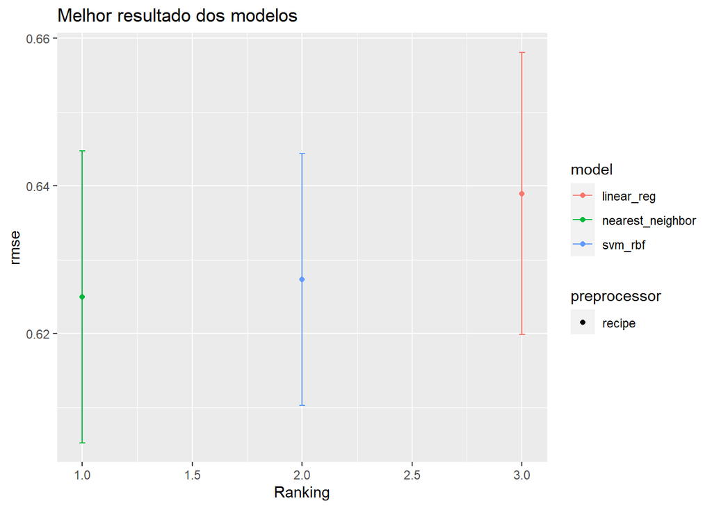

```r
autoplot(
  tunagem,
  rank_metric = "rmse",
  metric = "rmse",
  select_best = TRUE
) +
  labs(title = "Melhor resultado dos modelos")+ ylab("rmse")+ xlab("Ranking")
```

```r
best = tunagem %>%
  extract_workflow_set_result("modelo_knn") %>%
  select_best(metric = "rmse")

best %>%
  knitr::kable(caption = "Hiperparametros")
```

Hiperparametros

| neighbors | .config |
| --- | --- |
| 15 | Preprocessor1_Model15 |

```r
wf_final <-
  tunagem %>% extract_workflow("modelo_knn") %>%
  finalize_workflow(best)

teste <-
  wf_final %>%
  last_fit(split = splitted)

knitr::kable(teste$.metrics, caption = "Resultados")
```

Resultados

| .metric | .estimator | .estimate | .config |
| --- | --- | --- | --- |
| rmse | standard | 0.6682525 | Preprocessor1_Model1 |
| rsq | standard | 0.2994095 | Preprocessor1_Model1 |

```r
modelo_final <-
  wf_final |>
  fit(data3)
```

## Salvando o modelo

```r
# Salvando o modelo em um arquivo serializado
#saveRDS(modelo_final, file = "modelo_final.rds")

# Lendo o arquivo serializado com o modelo final
#load(file = "modelo_final.rds")

# Fazendo novas previsões
#predict(modelo_final, data3)
```

## Exercício 4

Considere o problema em que o objetivo é prever a variável `cooling_load` com base em algumas variáveis. Sua análise deve conter uma análise exploratória dos dados, utilizar um esquema de `k-folds` cross-validation, com `k=20` e considerar um esquema de data splitting na proporção 90% para treino e 10% para teste.

### Carregando o banco de dados

```r
url = "https://raw.githubusercontent.com/eraldof/machine_learning/main/energy_efficiency_data.csv"
data4 <- read.csv(url)
```

### Analise exploratória:

```r
skimr::skim(data4)
```

Data summary

| Name | data4 |
| --- | --- |
| Number of rows | 768 |
| Number of columns | 10 |
| _______________________ |  |
| Column type frequency: |  |
| numeric | 10 |
| ________________________ |  |
| Group variables | None |

**Variable type: numeric**

| skim_variable | n_missing | complete_rate | mean | sd | p0 | p25 | p50 | p75 | p100 | hist |
| --- | --- | --- | --- | --- | --- | --- | --- | --- | --- | --- |
| Relative_Compactness | 0 | 1 | 0.76 | 0.11 | 0.62 | 0.68 | 0.75 | 0.83 | 0.98 | ▇▆▃▃▂ |
| Surface_Area | 0 | 1 | 671.71 | 88.09 | 514.50 | 606.38 | 673.75 | 741.12 | 808.50 | ▅▅▇▅▇ |
| Wall_Area | 0 | 1 | 318.50 | 43.63 | 245.00 | 294.00 | 318.50 | 343.00 | 416.50 | ▃▅▇▂▂ |
| Roof_Area | 0 | 1 | 176.60 | 45.17 | 110.25 | 140.88 | 183.75 | 220.50 | 220.50 | ▃▃▁▁▇ |
| Overall_Height | 0 | 1 | 5.25 | 1.75 | 3.50 | 3.50 | 5.25 | 7.00 | 7.00 | ▇▁▁▁▇ |
| Orientation | 0 | 1 | 3.50 | 1.12 | 2.00 | 2.75 | 3.50 | 4.25 | 5.00 | ▇▇▁▇▇ |
| Glazing_Area | 0 | 1 | 0.23 | 0.13 | 0.00 | 0.10 | 0.25 | 0.40 | 0.40 | ▂▇▁▇▇ |
| Glazing_Area_Distribution | 0 | 1 | 2.81 | 1.55 | 0.00 | 1.75 | 3.00 | 4.00 | 5.00 | ▇▆▆▆▆ |
| Heating_Load | 0 | 1 | 22.31 | 10.09 | 6.01 | 12.99 | 18.95 | 31.67 | 43.10 | ▇▇▃▆▅ |
| Cooling_Load | 0 | 1 | 24.59 | 9.51 | 10.90 | 15.62 | 22.08 | 33.13 | 48.03 | ▇▂▅▃▁ |

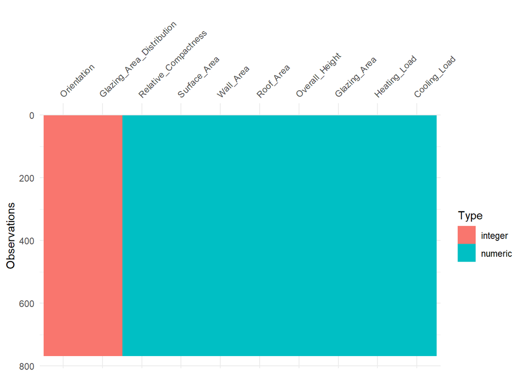

```r
visdat::vis_dat(data4)
```

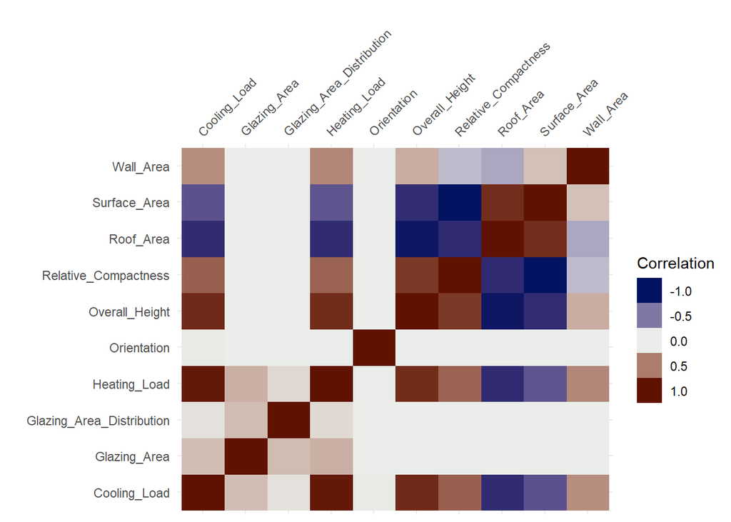

```r
visdat::vis_cor(data4)
```

O dataset possui 768 observações e 10 variáveis sendo elas 8 features e 2 labels, todas do tipo númerico. Estamos interessados em prever a variável `cooling_load`. Visualizando a primeira figura é possível notar que nosso banco não possui informações faltantes. Entretanto podemos notar uma alta correlação entre algumas de suas variáveis.

### Tratamento dos dados e preparação da receita:

```r
set.seed(2023)
splitted <- initial_split(data4, prop = 0.9, strata = Cooling_Load)
treinamento <- training(splitted)
teste <- testing(splitted)
```

```r
receita <- recipe(formula = `Cooling_Load` ~ . , data4) %>%
  step_corr(all_predictors()) %>%
  step_YeoJohnson(all_predictors()) %>%
  step_normalize(all_predictors())
```

**Dica:**

Com esses comandos podemos avaliar os procedimentos da receita na base de dados: `receita %>% prep() %>% juice()`

O banco de dados foi repartido em 90% para a base de treinamento e 10% para a base de teste, além disso, foi aplicado os seguintes passos na receita:

- `step_corr()`: Remove as variáveis com alta correlação;
- `step_YeoJohnson()`: Uma transformação similar a box-cox, entretanto mais generalizada;
- `step_normalize()`: Para normalizar as observações.

**Importante**

### Configurando os modelos:

```r
elastic <-
  linear_reg(penalty = tune(),
             mixture = tune()
  ) %>%
  set_mode("regression") %>%
  set_engine("glmnet")

knn <-
  nearest_neighbor(
    neighbors = tune()
  ) %>%
  set_mode("regression") %>%
  set_engine("kknn")

svm <-
  svm_rbf(
    cost = tune(),
    rbf_sigma = tune(),
    margin = tune()
  ) %>%
  set_mode("regression") %>%
  set_engine("kernlab")

all_wf <-
   workflow_set(
     preproc = list(receita),
     models = list(
       modelo_knn = knn,
       modelo_svm = svm,
       modelo_elastic = elastic
     ),
     cross = TRUE
   ) %>%
  mutate(wflow_id = gsub("(recipe_)", "", wflow_id))

grid_control <- control_grid(
  save_pred = TRUE,
  save_workflow = TRUE,
  parallel_over = "resamples"
)

vfold <-
  treinamento %>%
  vfold_cv(v = 15L, strata = Cooling_Load)

metrica <- metric_set(rmse)
```

**Dica:**

Com a função `grid_max_entropy()` podemos criar um grid de hiperpametros mais diversificado e através do `option_add()` informamos ao workflow qual grid utilizar em cada um dos modelos.

```r
set.seed(2023)
grid_knn <- grid_max_entropy(all_wf %>% extract_parameter_set_dials("modelo_knn"), size = 50L)
grid_elastic <- grid_max_entropy(all_wf %>% extract_parameter_set_dials("modelo_elastic"), size = 100L)
grid_svm <-  grid_max_entropy(all_wf %>% extract_parameter_set_dials("modelo_svm"), size = 30L)
```

```r
all_wf <-
  all_wf %>%
  option_add(grid = grid_knn, id = 'modelo_knn') %>%
  option_add(grid = grid_elastic, id = 'modelo_elastic') %>%
  option_add(grid = grid_svm, id = 'modelo_svm')
```

### Treinamento e Seleção:

```r
tunagem <-
  all_wf %>%
  workflow_map(
    verbose = TRUE,
    seed = 2023,
    resamples = vfold,
    control = grid_control,
    metrics = metrica
  )
```

```
i 1 of 3 tuning:     modelo_knn
```

```
✔ 1 of 3 tuning:     modelo_knn (3.5s)
```

```
i 2 of 3 tuning:     modelo_svm
```

```
✔ 2 of 3 tuning:     modelo_svm (37.4s)
```

```
i 3 of 3 tuning:     modelo_elastic
```

```
✔ 3 of 3 tuning:     modelo_elastic (1m 4.2s)
```

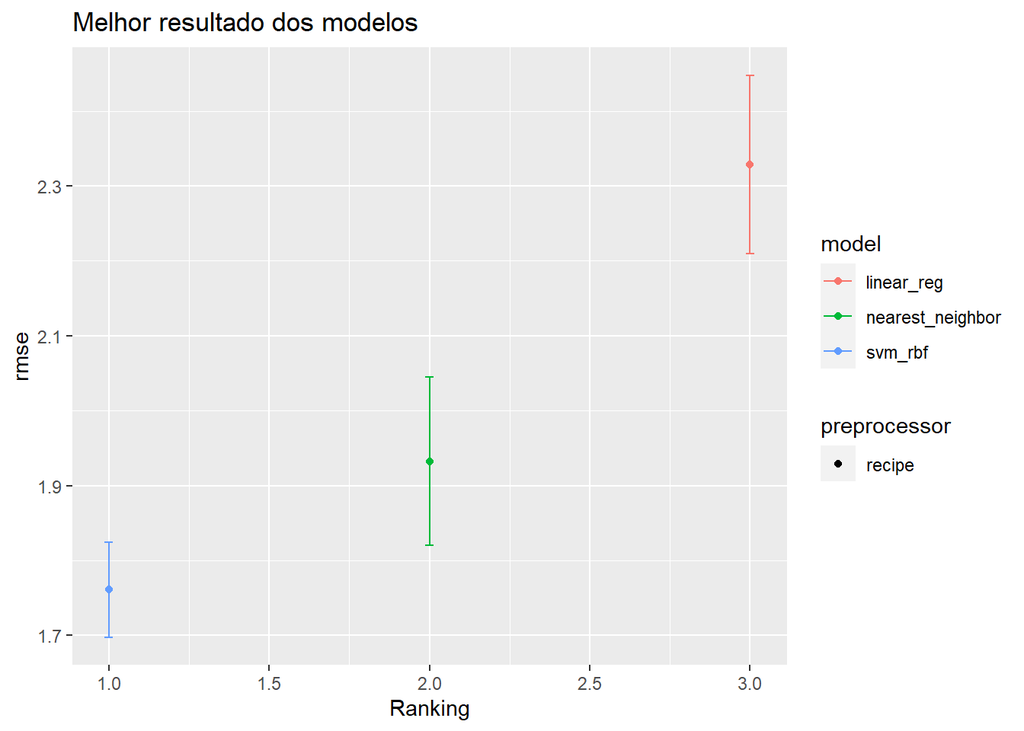

```r
autoplot(
  tunagem,
  rank_metric = "rmse",
  metric = "rmse",
  select_best = TRUE
) +
  labs(title = "Melhor resultado dos modelos")+ ylab("rmse")+ xlab("Ranking")
```

```r
best = tunagem %>%
  extract_workflow_set_result("modelo_svm") %>%
  select_best(metric = "rmse")

best %>%
  knitr::kable(caption = "Hiperparametros")
```

Hiperparametros

| cost | rbf_sigma | margin | .config |
| --- | --- | --- | --- |
| 12.77395 | 0.0677609 | 0.1971278 | Preprocessor1_Model02 |

```r
wf_final <-
  tunagem %>% extract_workflow("modelo_svm") %>%
  finalize_workflow(best)

teste <-
  wf_final %>%
  last_fit(split = splitted)

knitr::kable(teste$.metrics, caption = "Resultados")
```

Resultados

| .metric | .estimator | .estimate | .config |
| --- | --- | --- | --- |
| rmse | standard | 1.7441279 | Preprocessor1_Model1 |
| rsq | standard | 0.9663881 | Preprocessor1_Model1 |

```r
modelo_final <-
  wf_final %>%
  fit(data4)
```

## Salvando o modelo

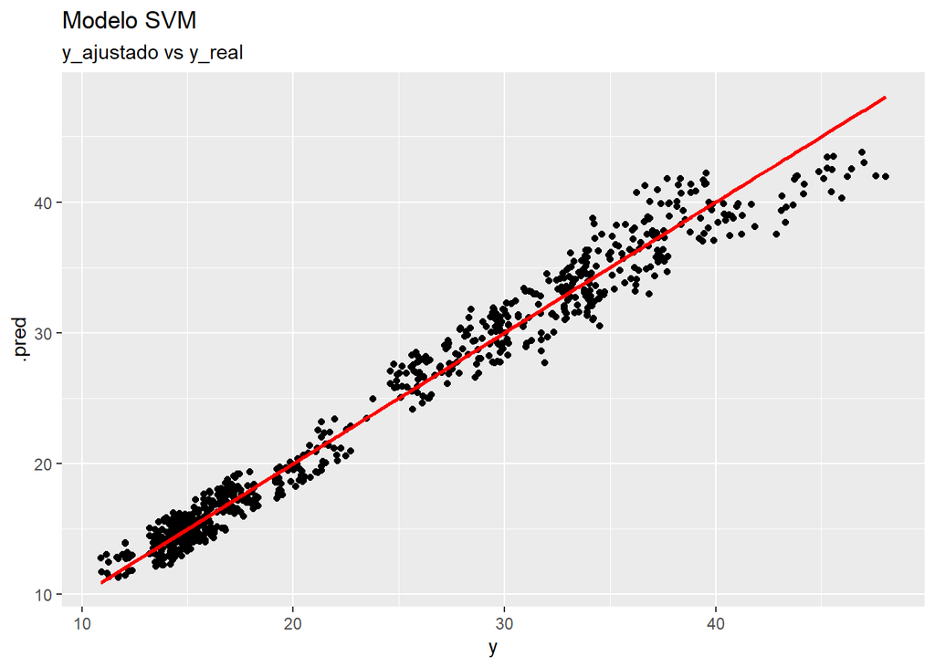

```r
# Salvando o modelo em um arquivo serializado
#saveRDS(modelo_final, file = "modelo_final.rds")

# Lendo o arquivo serializado com o modelo final
#load(file = "modelo_final.rds")

# Fazendo novas previsões
dt <- data.frame("y" = data4$Cooling_Load, "yhat" = predict(modelo_final, data4))
g1 <- ggplot(dt,
             aes(x = y, y = .pred)) +
  geom_point() + geom_line(aes(y = y), colour = "red", size = 1) +
  labs(title = "Modelo SVM", subtitle = "y_ajustado vs y_real")

g1
```